# question2 – In God We Trust, In AI We Ask

### Question 2 — Does Behavioral Religiosity Predict Frequency of Seeking Moral Advice from AI Chatbots?

While self-reported religiosity captures individuals’ global self-identification as religious, behavioral measures may provide a more nuanced and less socially desirable index of religious engagement. We constructed a **Religious Behavior Score** averaging two items: “How often do you attend religious services/ pray?” (1=*never*, 7=*once a day or more*) to capture both social and individual aspects of religious engagement. In the remaining main analyses, we use this score as the primary predictor, deferring self-reported religiosity to Supplementary.

We first examined whether Religious Behavior Score predicts AI moral advice seeking across both studies.

Table 1: Pearson Correlations Between Religious Behavior Score and Frequency of Seeking Moral Advice From AI Chatbots

| Study | N | r | t | df | p |
| --- | --- | --- | --- | --- | --- |
| Study 1 | 348 | 0.31 | 6.05 | 346 | <.001 |
| Study 2 | 347 | 0.33 | 6.51 | 345 | <.001 |

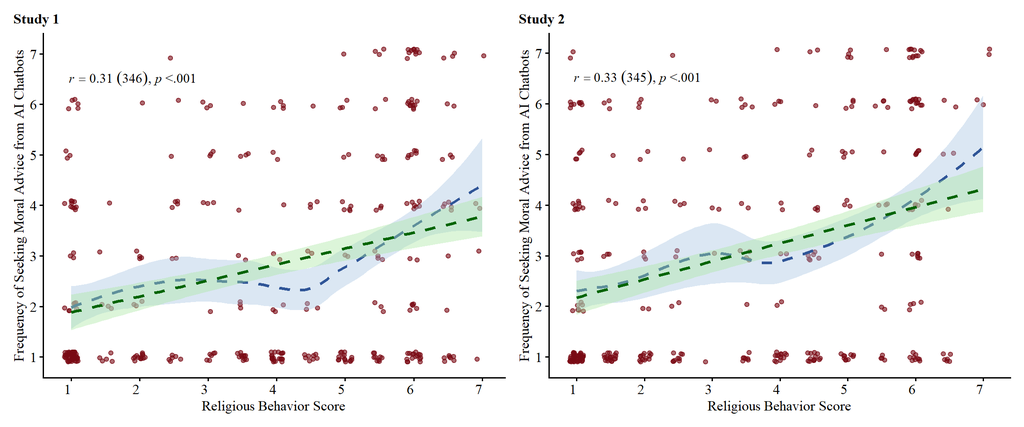

Figure 1: Religious Behavior Score and Frequency of Seeking Moral Advice from AI Chatbots

Table 2: Religious Behavior Score Predicting Frequency of Seeking Moral Advice from AI Chatbots

| Study | Model 1 b | Model 1 SE | Model 1 95% CI LL | Model 1 95% CI UL | Model 1 p | Model 2 b | Model 2 SE | Model 2 95% CI LL | Model 2 95% CI UL | Model 2 p |
| --- | --- | --- | --- | --- | --- | --- | --- | --- | --- | --- |
| Study 1 | 0.32 | 0.05 | 0.21 | 0.42 | < .001 | 0.30 | 0.06 | 0.18 | 0.42 | < .001 |
| Study 2 | 0.36 | 0.05 | 0.25 | 0.46 | < .001 | 0.30 | 0.06 | 0.18 | 0.42 | < .001 |

Religious Behavior Score consistently and positively predicted the frequency of seeking moral advice from AI chatbots in Studies 1 and 2, effects that were robust to the inclusion of demographic covariates.